Produced Saturday 23 January 2021

**This is one page of the R Handbook for Epidemiologists, but is being printed as a stand-alone page.**

**You can find the complete handbook on [Github](https://github.com/nsbatra/Epi_R_handbook)**

# Missing data

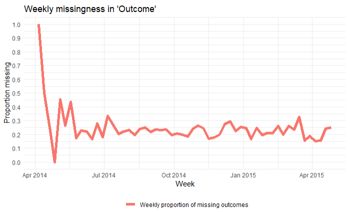

## Useful functions

## Useful functions

The following are useful functions when assessing or handling missing values:

**`is.na()` and `!is.na()`**

To identify missing values use `is.na()` or its opposite (with `!` in front). Both are from **base** R.  
These return a logical vector (`TRUE` or `FALSE`). Remember that you can `sum()` the resulting vector to count the number `TRUE`, e.g. `sum(is.na(linelist$date_outcome))`.

```r
my_vector <- c(1, 4, 56, NA, 5, NA, 22)
is.na(my_vector)
```

```
## [1] FALSE FALSE FALSE  TRUE FALSE  TRUE FALSE
```

```r
!is.na(my_vector)
```

```
## [1]  TRUE  TRUE  TRUE FALSE  TRUE FALSE  TRUE
```

**`na.omit()`**

This function, if applied to a dataframe, will remove rows with *any* missing values. It is also from **base** R.  
If applied to a vector, it will remove `NA` values from the vector it is applied to. For example:

```r
sum(na.omit(my_vector))
```

```
## [1] 88
```

**`na.rm = TRUE`**

Often a mathematical function will by default *include* `NA` in calculations, which results in the function returning `NA` (this is designed intentionally, to make you aware that you have missing data).  
You can usually avoid this by removing missing values from the calculation, by including the argument `na.rm = TRUE` (na.rm stands for “remove `NA`”).

```r
mean(my_vector)
```

```
## [1] NA
```

```r
mean(my_vector, na.rm = TRUE)
```

```
## [1] 17.6
```

## Assess a dataframe

## Assess a dataframe

## Missingness over time

## Over time

```r
outcome_missing <- linelist %>%
  mutate(week = lubridate::floor_date(date_onset, "week")) %>%
  group_by(week) %>%
  summarize(n_obs = n(),
            outcome_missing = sum(is.na(outcome) | outcome == ""), # include "" because this is character
            outcome_p_miss = outcome_missing / n_obs) %>%
  reshape2::melt(id.vars = c("week")) %>%
  filter(grepl("_p_", variable))
```

Then we plot the proportion missing as a line, by week

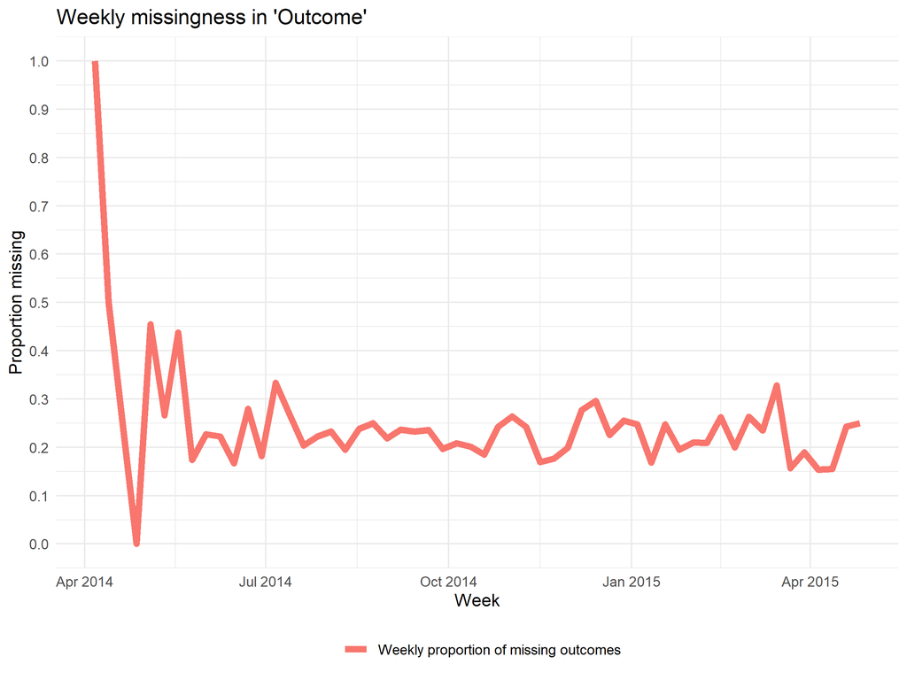

```r
ggplot(data = outcome_missing)+
    geom_line(aes(x = week, y = value, group = variable, color = variable), size = 2, stat = "identity")+
    labs(title = "Weekly missingness in 'Outcome'",
         x = "Week",
         y = "Proportion missing") +
    scale_color_discrete(name = "", labels = c("Weekly proportion of missing outcomes"))+
    scale_y_continuous(breaks = c(seq(0,1,0.1)))+
  theme_minimal()+
  theme(
    legend.position = "bottom"
  )
```

## `NA` in plots

## `NA` in plots

## Imputation

## Imputation

## Resources

## Resources